# Investigating Strange data

Muhammad Fauzan

2022-05-30

## The purpose of this project:

The bike store sales europe dataset contains the sales data of a bikestore with 18 columns and 113036 rows.

The purpose of this analyses is to figure out why the recorded profits in the data is not aligned with the order quantity, unit price, and unit cost data.

#### Bike Sales Dataset in Europe

Downloaded from <kaggle.com/code/sadiqshah/bike-store-sales-in-europe/data>

### Importing packages

```r
library(tidyverse)
library(janitor)
library(here)
```

## Inspecting the problem:

The dataset contains information on the order quantity, unit price, and unit cost in each purchase.

```r
Sales <- read_csv("Dataset1 - Sales.csv")
head(select(Sales, Order_Quantity:Revenue))
```

```
## # A tibble: 6 × 6
##   Order_Quantity Unit_Cost Unit_Price Profit  Cost Revenue
##            <dbl>     <dbl>      <dbl>  <dbl> <dbl>   <dbl>
## 1              8        45        120    590   360     950
## 2              8        45        120    590   360     950
## 3             23        45        120   1366  1035    2401
## 4             20        45        120   1188   900    2088
## 5              4        45        120    238   180     418
## 6              5        45        120    297   225     522
```

A simple calculation show how the recorded revenue is not aligned with the data. I took this chance to clean the data and calculate the gap of profit and the percentage of the revenue it represents

### Cleaning and transforming the data

```r
scleaned <- Sales %>%
  clean_names() %>%
  mutate(
    real_profit = (order_quantity * unit_price) - (order_quantity * unit_cost),
    profit_gap = real_profit - profit,
    p_gap_percent = profit_gap/revenue*100
  )

head(select(scleaned, profit:p_gap_percent, -(cost:revenue)))
```

```
## # A tibble: 6 × 4
##   profit real_profit profit_gap p_gap_percent
##    <dbl>       <dbl>      <dbl>         <dbl>
## 1    590         600         10          1.05
## 2    590         600         10          1.05
## 3   1366        1725        359         15.0
## 4   1188        1500        312         14.9
## 5    238         300         62         14.8
## 6    297         375         78         14.9
```

## Solution:

I decided to do some data exploration with visualizations to uncover potential correlations in the data. This way we may be able to deduce the reason for this discrepancy.

The first potential correlation lies in my hypothesis, which is this discrepancy is caused by an unrecorded discount or tax scheme. So the first graph shows the relationship of revenue and profit gap

### Create a graph showing the relationship of revenue and profit gap

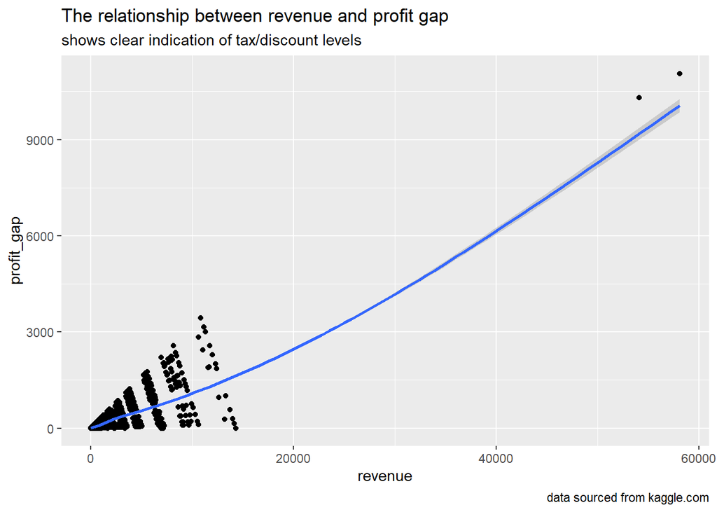

```r
scleaned %>%
  ggplot() +
  geom_point(aes(x = revenue, y = profit_gap))+
  geom_smooth(aes(x = revenue, y = profit_gap))+
  labs(title = "The relationship between revenue and profit gap",
       subtitle = 'shows clear indication of tax/discount levels',
       caption = 'data sourced from kaggle.com'
       )
```

### Filter out outliers

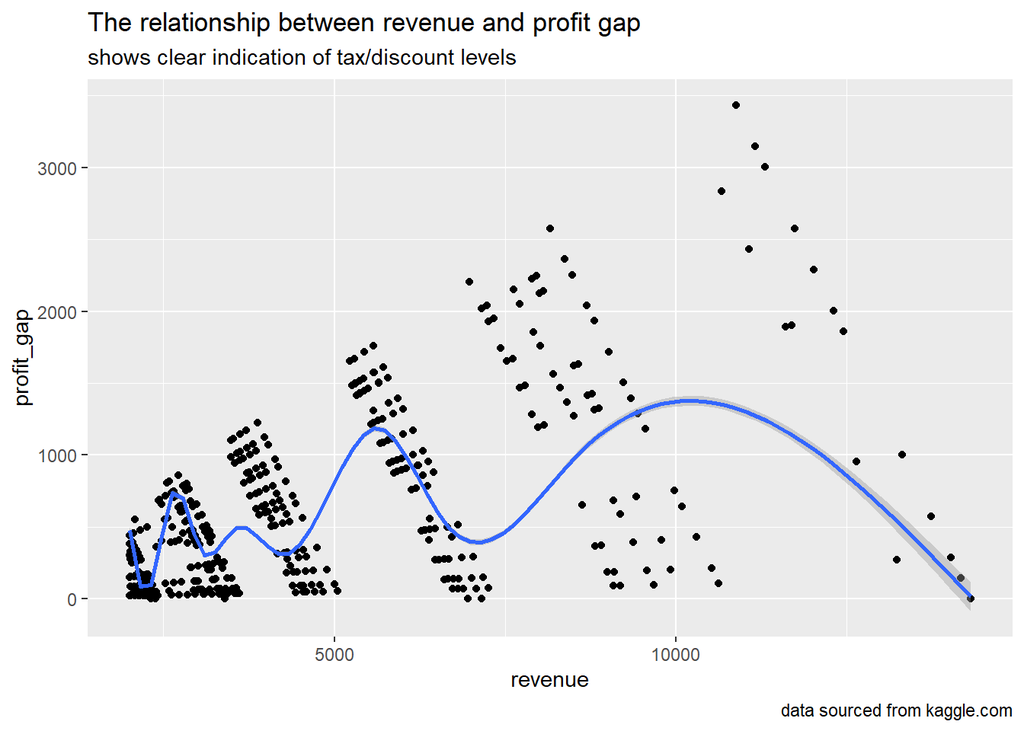

```r
scleaned %>%
  filter(between(revenue, 2000, 16000)) %>%
  ggplot() +
  geom_point(aes(x = revenue, y = profit_gap))+
  geom_smooth(aes(x = revenue, y = profit_gap))+
  labs(title = "The relationship between revenue and profit gap",
       subtitle = 'shows clear indication of tax/discount levels',
       caption = 'data sourced from kaggle.com'
       )
```

### Clarify the relationship between revenue size and profit gap

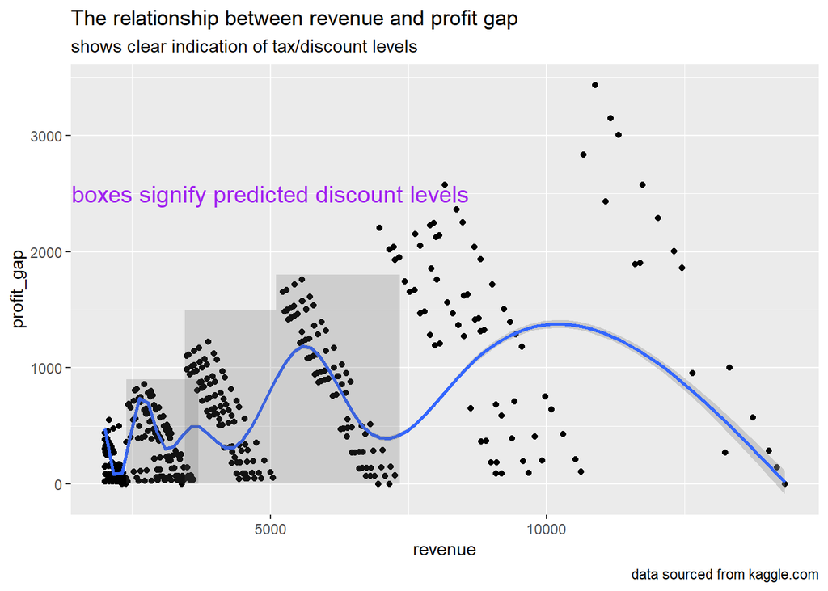

```r
scleaned %>%
  filter(between(revenue, 2000, 16000)) %>%
  ggplot() +
  geom_point(aes(x = revenue, y = profit_gap))+
  geom_smooth(aes(x = revenue, y = profit_gap))+
  labs(title = "The relationship between revenue and profit gap",
       subtitle = 'shows clear indication of tax/discount levels',
       caption = 'data sourced from kaggle.com'
       )+
  annotate("rect", xmin = 3450, xmax = 5100, ymin = 0, ymax = 1500, alpha = .2)+
  annotate("rect", xmin = 5100, xmax = 7350, ymin = 0, ymax = 1800, alpha = .2)+
  annotate("rect", xmin = 2400, xmax = 3700, ymin = 0, ymax = 900, alpha = .2)+
  annotate("text",
           x = 5000,
           y = 2500,
           label = "boxes signify predicted discount levels",
           color = "purple",
           size = 5
           )
```

#### It looks like there are discount/tax categories that each purchace falls into

Next we will explore other potential relationships to the profit gap, starting with date.

### Graph comparing the relationship between date and profit gap, and the relationship between date and revenue

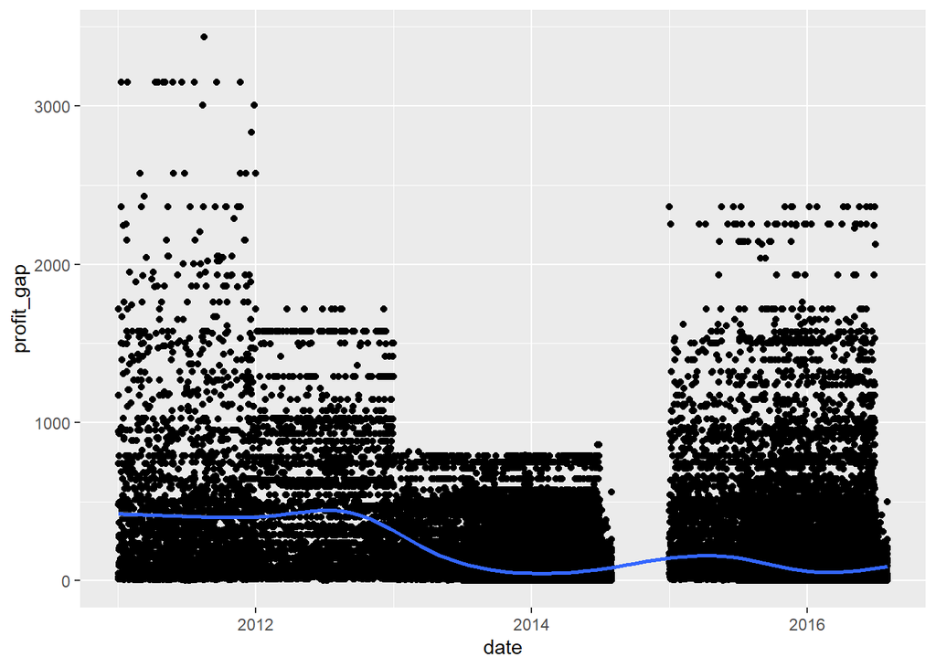

```r
scleaned %>%
  filter(profit_gap < 6000) %>%
  ggplot() +
  geom_point(aes(x = date, y = profit_gap))+
  geom_smooth(aes(x = date, y = profit_gap))
```

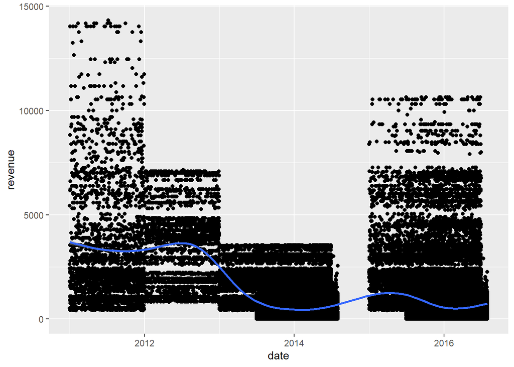

```r
scleaned %>%
  filter(revenue < 40000) %>%
  ggplot() +
  geom_point(aes(x = date, y = revenue))+
  geom_smooth(aes(x = date, y = revenue))
```

#### These two graphs show that profit gap is not affected by date, rather it is affected by the revenue in each year

The next suspect for this profit gap is the product itself, there might be product specific discounts. In that case I calculated the average profit gap, max profit gap, and min profit gap to see if there is any pattern

```r
scleaned %>%
  group_by(sub_category) %>%
  summarize(avg_profit_gap_percent = mean(p_gap_percent),max_profit_gap_percent = max(p_gap_percent),
            min_profit_gap_percent = min(p_gap_percent))
```

```
## # A tibble: 17 × 4
##    sub_category      avg_profit_gap_percent max_profit_gap_per… min_profit_gap_…
##    <chr>                              <dbl>               <dbl>            <dbl>
##  1 Bike Racks                          11.1                31.9            0
##  2 Bike Stands                         12.3                31.6            0.952
##  3 Bottles and Cages                   11.1                36.4            0
##  4 Caps                                11.2                33.3            0
##  5 Cleaners                            11.7                33.3            0
##  6 Fenders                             10.7                32              0
##  7 Gloves                              11.0                33.3            0
##  8 Helmets                             11.6                32.1            0
##  9 Hydration Packs                     11.4                31.7            0.917
## 10 Jerseys                             11.7                31.7            0
## 11 Mountain Bikes                      12.2                31.7            0
## 12 Road Bikes                          12.9                31.7            0
## 13 Shorts                              10.4                31.6            0.719
## 14 Socks                               11.0                33.3            0
## 15 Tires and Tubes                     11.2                36.4            0
## 16 Touring Bikes                       11.6                31.6            0
## 17 Vests                               11.4                31.6            0.787
```

## Conclusion:

There seems to be a clear correlation between revenue/sales size and the profit gap. This makes sense if there is a discount or tax scheme that is structured based on each purchases size.

### Limitation:

Although I have the data and analyses to strengthen my hypothesis. I can not say for certain that this conjecture is correct. Because there is a lack of qualitative data in this dataset to confirm or deny my hypothesis